# R Notebook

### Hillary Clinton’s emails (background from https://www.kaggle.com/kaggle/hillary-clinton-emails)

Throughout 2015, Hillary Clinton has been embroiled in controversy over the use of personal email accounts on non-government servers during her time as the United States Secretary of State. Some political experts and opponents maintain that Clinton’s use of personal email accounts to conduct Secretary of State affairs is in violation of protocols and federal laws that ensure appropriate recordkeeping of government activity. Hillary’s campaign has provided their own four sentence summary of her email use here.

There have been a number of Freedom of Information lawsuits filed over the State Department’s failure to fully release the emails sent and received on Clinton’s private accounts. On Monday, August 31, 2015 the State Department released nearly 7,000 pages of Clinton’s heavily redacted emails (its biggest release of emails to date).

The documents were released by the State Department as PDFs. We’ve cleaned and normalized the released documents and are hosting them for public analysis. Kaggle’s choice to host this dataset is not meant to express any particular political affiliation or intent.

### Load required libraries for analysis

```r
library(tidyverse)
library(knitr)
library(ggplot2)
library(readr)
library(RSQLite)
library(network)
library(sna)
library(GGally)
library(dplyr)
opts_knit$set(root.dir = normalizePath(".."))
projDir <- opts_knit$get("root.dir")
nbDir <- file.path(projDir,"data-visualization")
dataDir <- file.path(nbDir,"data","assignment_02")
figDir <- file.path(nbDir,"figs")
print(paste("Project Directory: ", projDir))
```

```
[1] "Project Directory:  /Users/galen/Dropbox/github_projects/uillinois-data-mining"
```

```r
print(paste("Notebook Directory: ", nbDir))
```

```
[1] "Notebook Directory:  /Users/galen/Dropbox/github_projects/uillinois-data-mining/data-visualization"
```

```r
print(paste("Data Directory: ", dataDir))
```

```
[1] "Data Directory:  /Users/galen/Dropbox/github_projects/uillinois-data-mining/data-visualization/data/assignment_02"
```

```r
print(paste("Figures Directory: ", figDir))
```

```
[1] "Figures Directory:  /Users/galen/Dropbox/github_projects/uillinois-data-mining/data-visualization/figs"
```

### Initialize connection to `sqllite` database

```r
drv <- SQLite()
# connect to the sqlite file
conn <- dbConnect(drv, dbname=file.path(dataDir,"database.sqlite"))
# get a list of all tables
alltables = dbListTables(conn)
```

### Get table information from the `sqllite` database

```r
senders <- dbReadTable(conn, "Aliases")
receivers <- dbReadTable(conn,"EmailReceivers")
persons <- dbReadTable(conn,"Persons")
emails <- dbReadTable(conn,"Emails")
email_fields <- dbListFields(conn, "Emails")
email_fields
```

```
 [1] "Id"                           "DocNumber"
 [3] "MetadataSubject"              "MetadataTo"
 [5] "MetadataFrom"                 "SenderPersonId"
 [7] "MetadataDateSent"             "MetadataDateReleased"
 [9] "MetadataPdfLink"              "MetadataCaseNumber"
[11] "MetadataDocumentClass"        "ExtractedSubject"
[13] "ExtractedTo"                  "ExtractedFrom"
[15] "ExtractedCc"                  "ExtractedDateSent"
[17] "ExtractedCaseNumber"          "ExtractedDocNumber"
[19] "ExtractedDateReleased"        "ExtractedReleaseInPartOrFull"
[21] "ExtractedBodyText"            "RawText"
```

### Which emails?

```r
top <- receivers %>%
  group_by(EmailId) %>%
  summarise(count = n()) %>%
  top_n(5)
kable(top)
```

| EmailId | count |
| --- | --- |
| 1942 | 7 |
| 3879 | 6 |
| 3906 | 7 |
| 5163 | 6 |
| 5187 | 6 |
| 5192 | 6 |

Code to get the subject and sender

```r
tj <- top %>%
  select(EmailId) %>%
  inner_join(receivers, by=c("EmailId"="EmailId")) %>%
  select(EmailId,PersonId)
esn <- tj %>%
  inner_join(persons, by=c("PersonId"="Id"))
esj <- emails %>%
  select(Id,MetadataSubject) %>%
  inner_join(esn, by=c("Id"="EmailId"))
esj[esj==""] <- NA
e <- esj %>%
  select(Name,MetadataSubject) %>%
  drop_na() %>%
  rename(subject=MetadataSubject,name=Name) %>%
  mutate(subject=tolower(subject), name=tolower(name))
```

### Create the network object for plotting

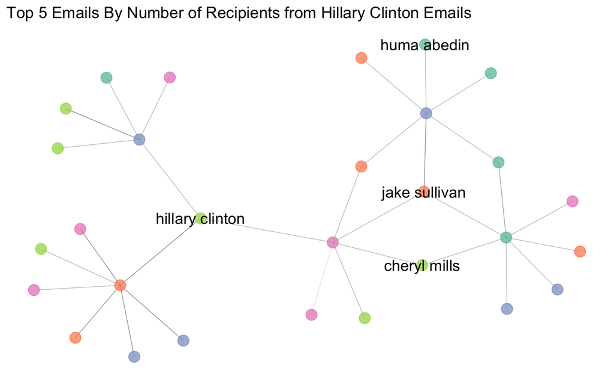

```r
net = network(e, directed = FALSE)
# email subject
x = factor(unique(e$subject))
net %v% "name" = as.character(x)
ggnet2(net, color = "name", alpha = 0.75, size = 4, edge.alpha = 0.5,
       edge.color = c("color", "grey50"), label = c("hillary clinton","cheryl mills","jake sullivan","huma abedin")) + theme(legend.position = "none") + labs(title = "Top 5 Emails By Number of Recipients from Hillary Clinton Emails") + scale_color_brewer(palette = "Set2")
```

Save down the png file

```r
ggsave(file.path(figDir,"assignment02.png"), width = 15, height = 8)
```

Code to grab text body from emails sent by Hillary.

```r
emailsFromHillary <- dbGetQuery(conn, "SELECT ExtractedBodyText EmailBody FROM Emails e INNER JOIN Persons p ON e.SenderPersonId=p.Id WHERE p.Name='Hillary Clinton'  AND e.ExtractedBodyText != '' ORDER BY RANDOM()")
```